# Assignment 6 Task 3

Logan Babcock

### Introduction

This report will compare total lengths in millimeters for female lizards of two species: *Cnemidophorus uniparens*, the Desert Grassland lizard, and *Cnemidophorus tessalatus*, the Colorado Checkered lizard. The data will analyzed using a Cohen's D test `cohen.d()`, to find the effect size of the difference in means. This wil let us assess if there is a significant difference in total length difference in mean total length between female lizards for the two species.

### Visualizing Lizard Lengths

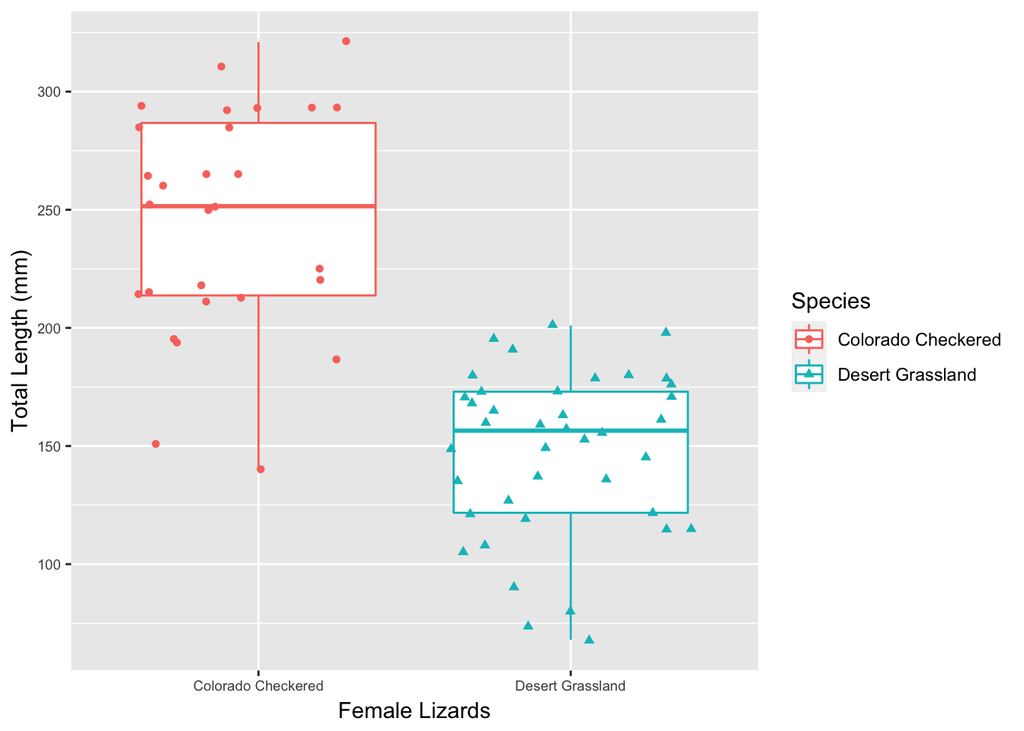

### Summary Table and Statistics

**Table 1:** Summary table showing the mean, standard deviation, median length, and count of female lizards by species.

| Species | Mean | Standard Deviation | Median Length (mm) | Count |
| --- | --- | --- | --- | --- |
| Colorado Checkered | 244.89 | 47.32 | 251.5 | 28 |
| Desert Grassland | 147.60 | 34.55 | 156.5 | 40 |

The effect size is large, with a Cohen's D of (Cohen's *d* = 2.416). The difference between the means is significant (two-sample t-test, t = 9.283, p < 0.01). The actual difference in means is 97.293. The large effect size and T-Test result means that we would reject the hypothesis that both species populations mean length's are the same

**Data Citation:** Lightfoot, D. 2017. Lizard pitfall trap data (LTER-II, LTER-III) ver 36. Environmental Data Initiative. https://doi.org/10.6073/pasta/ff37b4cace16a9943575f3fd7067064e